# SOX Factor Decomposition & SOXL Strategy Intelligence

# 1 Executive Summary

This report turns SOX from a simple reference index into a decision layer for SOXL trading. It decomposes the semiconductor complex across index behavior, industry structure, rate sensitivity, Nasdaq 100 relative strength, constituent contribution, lead-lag behavior, and a rule-based regime label.

```r
signal_tbl |>
  mutate(
    rate_beta = round(rate_beta, 4)
  ) |>
  knitr::kable()
```

| as_of | current_regime | sox_volatility | relative_strength | rate_beta | suggested_action |
| --- | --- | --- | --- | --- | --- |
| 2026-06-12 | Broad Rally | Moderate | Strong | 0.0763 | Maintain baseline exposure |

# 2 What Is SOX?

The PHLX Semiconductor Index, commonly tracked as SOX, is a Nasdaq-owned semiconductor index built from 30 large U.S.-traded semiconductor-related companies. It is useful for SOXL because SOXL is designed to deliver a daily leveraged semiconductor exposure, so the quality of the underlying SOX move matters more than the SOXL price alone.

Practical interpretation:

- SOX strength with broad constituent participation is usually healthier for SOXL exposure.
- SOX strength led only by a small AI cluster can still be profitable, but the strategy should avoid raising anchors too aggressively.
- SOX weakness during a rate shock usually deserves faster exposure reduction because leveraged ETF decay compounds drawdowns.

# 3 Constituents

The constituent table below is a maintained fallback universe based on the SOX 30-company structure. The report uses equal weights when official point-in-time weights are unavailable, so contribution scores should be treated as a directional influence model rather than official index attribution.

## 3.1 Industry Structure Guide

SOX is not a single homogeneous semiconductor bet. It mixes chip designers, manufacturers, fab equipment suppliers, memory producers, analog/auto names, materials, packaging, and RF suppliers. The table below explains what each group does and how to interpret its strength for SOXL operation.

```r
industry_structure_guide |>
  knitr::kable()
```

| industry_group | role_in_value_chain | what_it_signals | soxl_operator_read |
| --- | --- | --- | --- |
| Fabless | Designs chips but outsources manufacturing. Includes GPU, CPU, mobile, networking, and custom silicon leaders. | Demand for AI compute, data center capex, mobile/edge cycles, and product leadership. | Leadership here supports upside participation, but crowded AI-led rallies can reverse quickly if breadth narrows. |
| Fabless/IP | Provides interface IP and chip architecture building blocks used by other semiconductor firms. | Memory bandwidth, interface standards, and licensing demand. | Usually a secondary confirmation signal rather than the main driver of SOXL exposure. |
| Foundry | Manufactures chips for fabless customers. Advanced foundry capacity is the bottleneck for leading-edge AI and compute chips. | End-demand visibility, wafer starts, utilization, and supply constraints. | Strong foundry participation makes a rally healthier because design demand is being confirmed by manufacturing demand. |
| Equipment | Sells lithography, etch, deposition, metrology, and test equipment used to build fabs. | Capex cycle, fab expansion, process migration, and long-cycle semiconductor investment. | Equipment leadership often means a capex cycle. It can support medium-term exposure but may lag sudden demand shocks. |
| Memory | Produces DRAM and NAND. Highly cyclical and sensitive to pricing, inventory, and AI memory demand. | Memory price cycle, inventory digestion, HBM demand, and operating leverage. | Memory leadership can produce strong SOXL beta, but reversals can be sharp when pricing expectations change. |
| Analog | Produces industrial, automotive, and power-management analog semiconductors. | Industrial demand, auto cycle, inventory normalization, and broad economic conditions. | Analog strength is a breadth-quality signal. Weak analog while AI leaders rally suggests narrower participation. |
| Analog/MCU | Combines microcontrollers and analog chips used in embedded, industrial, and automotive systems. | Industrial and auto embedded demand. | Useful for detecting whether the rally extends beyond AI/data-center names. |
| Analog/Power | Power management chips for compute, industrial, and consumer devices. | Power density, efficiency, and broad device demand. | A stabilizing breadth signal; less explosive than Fabless but helpful for confirming broad participation. |
| Power | Power semiconductors including SiC and automotive/industrial power devices. | EV, industrial power, renewable infrastructure, and power efficiency cycles. | Can diverge from AI cycles. Weakness here may not kill SOXL, but it reduces breadth quality. |
| Auto/MCU | Automotive and industrial controllers, sensors, and embedded processors. | Auto production, industrial capex, and inventory cycle. | A cyclical breadth check; strength lowers the chance that SOX is only an AI concentration trade. |
| Auto/Power | Automotive sensors and power-related semiconductors. | Auto electronics content and powertrain demand. | A supporting breadth indicator rather than a primary SOXL timing signal. |
| Packaging | Assembly, test, and advanced packaging services that connect dies, memory, substrates, and systems. | Advanced packaging bottlenecks, AI accelerator buildout, and backend capacity. | Strength here can confirm AI hardware demand beyond the headline chip designers. |
| Materials | Supplies chemicals, filters, wafers, and consumables used in semiconductor manufacturing. | Fab utilization, process complexity, and manufacturing intensity. | Materials strength is a quiet confirmation that production demand is broadening. |
| Materials/Photonics | Optical, laser, and photonics components used in communications, manufacturing, and advanced systems. | Optical networking, AI interconnect, and laser/photonics demand. | Useful for detecting AI infrastructure spillover, but usually not sufficient alone for aggressive exposure. |
| RF | Radio-frequency front-end components for mobile, wireless, and connectivity devices. | Smartphone cycle, wireless demand, and consumer electronics recovery. | RF strength broadens the rally outside AI; RF weakness warns that consumer semi demand remains soft. |
| IDM | Integrated device manufacturer that designs and manufactures chips internally. | Manufacturing execution, CPU demand, foundry strategy, and legacy/advanced node competitiveness. | Can be idiosyncratic. Treat as a regime color rather than a clean SOXL direction signal. |

Practical interpretation:

- **Fabless / AI leaders** explain fast upside and crowding risk.
- **Foundry / Equipment / Materials / Packaging** confirm whether demand is spreading into the production chain.
- **Memory** often gives SOXL strong beta, but it is highly cyclical.
- **Analog / Auto / RF / Power** are breadth checks. Strength here means the rally is less dependent on a few AI names.

```r
constituents |>
  select(ticker, company, industry_group, cycle_bucket, ai_sensitivity, default_weight) |>
  mutate(default_weight = percent(default_weight, accuracy = 0.1)) |>
  knitr::kable()
```

| ticker | company | industry_group | cycle_bucket | ai_sensitivity | default_weight |
| --- | --- | --- | --- | --- | --- |
| NVDA | NVIDIA | Fabless | AI accelerator | High | 3.3% |
| AVGO | Broadcom | Fabless | AI networking/custom silicon | High | 3.3% |
| AMD | Advanced Micro Devices | Fabless | CPU/GPU | High | 3.3% |
| QCOM | Qualcomm | Fabless | Mobile/edge | Medium | 3.3% |
| MRVL | Marvell Technology | Fabless | AI networking/storage | High | 3.3% |
| LSCC | Lattice Semiconductor | Fabless | FPGA | Medium | 3.3% |
| RMBS | Rambus | Fabless/IP | Memory interface/IP | Medium | 3.3% |
| TSM | Taiwan Semiconductor Manufacturing | Foundry | Leading-edge foundry | High | 3.3% |
| GFS | GLOBALFOUNDRIES | Foundry | Specialty foundry | Low | 3.3% |
| ASML | ASML Holding | Equipment | Lithography | High | 3.3% |
| AMAT | Applied Materials | Equipment | Wafer fab equipment | Medium | 3.3% |
| LRCX | Lam Research | Equipment | Etch/deposition | Medium | 3.3% |
| KLAC | KLA | Equipment | Process control | Medium | 3.3% |
| TER | Teradyne | Equipment | Test | Medium | 3.3% |
| ACLS | Axcelis Technologies | Equipment | Ion implantation | Low | 3.3% |
| MU | Micron Technology | Memory | DRAM/NAND | High | 3.3% |
| TXN | Texas Instruments | Analog | Industrial analog | Low | 3.3% |
| ADI | Analog Devices | Analog | Industrial analog | Low | 3.3% |
| MCHP | Microchip Technology | Analog/MCU | MCU/analog | Low | 3.3% |
| MPWR | Monolithic Power Systems | Analog/Power | Power management | Medium | 3.3% |
| ON | ON Semiconductor | Power | Auto/power | Low | 3.3% |
| WOLF | Wolfspeed | Power | SiC | Low | 3.3% |
| NXPI | NXP Semiconductors | Auto/MCU | Auto/industrial | Low | 3.3% |
| ALGM | Allegro MicroSystems | Auto/Power | Auto sensors | Low | 3.3% |
| AMKR | Amkor Technology | Packaging | OSAT | Medium | 3.3% |
| ENTG | Entegris | Materials | Materials/consumables | Medium | 3.3% |
| COHR | Coherent | Materials/Photonics | Optical components | Medium | 3.3% |
| QRVO | Qorvo | RF | RF front-end | Low | 3.3% |
| SWKS | Skyworks Solutions | RF | RF front-end | Low | 3.3% |
| INTC | Intel | IDM | CPU/foundry | Medium | 3.3% |

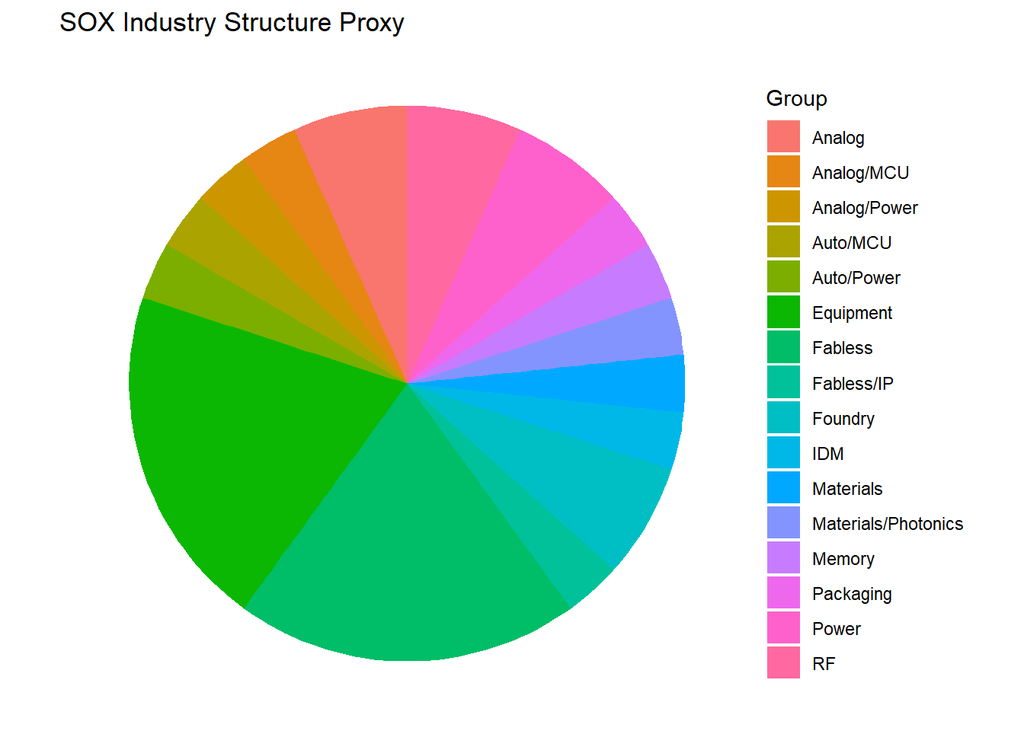

```r
constituents |>
  count(industry_group, wt = default_weight, name = "weight") |>
  ggplot(aes(x = "", y = weight, fill = industry_group)) +
  geom_col(width = 1) +
  coord_polar(theta = "y") +
  scale_y_continuous(labels = percent) +
  labs(title = "SOX Industry Structure Proxy", x = NULL, y = NULL, fill = "Group") +
  theme_void()
```

# 4 Descriptive Statistics

```r
stats_tbl |>
  mutate(
    annual_return = percent(annual_return, accuracy = 0.1),
    annual_vol = percent(annual_vol, accuracy = 0.1),
    sharpe = round(sharpe, 2),
    sortino = round(sortino, 2),
    mdd = percent(mdd, accuracy = 0.1),
    skewness = round(skewness, 2),
    kurtosis = round(kurtosis, 2)
  ) |>
  arrange(symbol, window) |>
  knitr::kable()
```

| symbol | window | start_date | end_date | observations | annual_return | annual_vol | sharpe | sortino | mdd | skewness | kurtosis | crash_3pct | crash_5pct | crash_7pct |
| --- | --- | --- | --- | --- | --- | --- | --- | --- | --- | --- | --- | --- | --- | --- |
| QQQ | Full | 1999-03-10 | 2026-06-12 | 6857 | 10.9% | 26.9% | 0.52 | 0.84 | -83.0% | 0.23 | 7.15 | 277 | 57 | 18 |
| QQQ | Last 10Y | 2016-06-06 | 2026-06-12 | 2520 | 21.5% | 22.4% | 0.98 | 1.56 | -35.1% | -0.20 | 7.69 | 64 | 9 | 2 |
| QQQ | Last 3Y | 2023-06-08 | 2026-06-12 | 756 | 28.2% | 19.9% | 1.34 | 2.23 | -22.8% | 0.52 | 11.85 | 10 | 2 | 0 |
| QQQ | Last 5Y | 2021-06-08 | 2026-06-12 | 1260 | 17.2% | 22.5% | 0.82 | 1.35 | -35.1% | 0.17 | 5.32 | 29 | 4 | 0 |
| SMH | Full | 2000-06-05 | 2026-06-12 | 6544 | 10.9% | 34.9% | 0.47 | 0.79 | -85.9% | 0.27 | 4.56 | 438 | 120 | 29 |
| SMH | Last 10Y | 2016-06-06 | 2026-06-12 | 2520 | 37.3% | 32.8% | 1.13 | 1.87 | -45.3% | -0.08 | 4.92 | 149 | 33 | 10 |
| SMH | Last 3Y | 2023-06-08 | 2026-06-12 | 756 | 63.2% | 35.1% | 1.57 | 2.64 | -35.7% | 0.11 | 6.06 | 50 | 13 | 6 |
| SMH | Last 5Y | 2021-06-08 | 2026-06-12 | 1260 | 38.6% | 35.4% | 1.10 | 1.88 | -45.3% | 0.17 | 3.86 | 90 | 20 | 6 |
| SOXL | Full | 2010-03-11 | 2026-06-12 | 4089 | 44.5% | 90.1% | 0.86 | 1.43 | -90.5% | 0.01 | 5.02 | 924 | 555 | 337 |
| SOXL | Last 10Y | 2016-06-06 | 2026-06-12 | 2520 | 62.5% | 99.9% | 0.99 | 1.64 | -90.5% | -0.01 | 4.89 | 598 | 377 | 248 |
| SOXL | Last 3Y | 2023-06-08 | 2026-06-12 | 756 | 122.8% | 109.0% | 1.28 | 2.15 | -87.9% | 0.21 | 6.57 | 182 | 124 | 84 |
| SOXL | Last 5Y | 2021-06-08 | 2026-06-12 | 1260 | 44.1% | 108.8% | 0.88 | 1.50 | -90.5% | 0.22 | 4.27 | 338 | 228 | 154 |
| ^GSPC | Full | 1995-01-03 | 2026-06-12 | 7913 | 9.3% | 18.8% | 0.57 | 0.90 | -56.8% | -0.16 | 10.25 | 105 | 22 | 7 |
| ^GSPC | Last 10Y | 2016-06-06 | 2026-06-12 | 2520 | 13.5% | 18.1% | 0.79 | 1.22 | -33.9% | -0.38 | 15.83 | 33 | 6 | 3 |
| ^GSPC | Last 3Y | 2023-06-08 | 2026-06-12 | 756 | 20.3% | 14.9% | 1.31 | 2.16 | -18.9% | 0.55 | 16.36 | 3 | 1 | 0 |
| ^GSPC | Last 5Y | 2021-06-08 | 2026-06-12 | 1260 | 11.9% | 16.9% | 0.75 | 1.23 | -25.4% | 0.15 | 7.06 | 11 | 1 | 0 |
| ^NDX | Full | 1995-01-03 | 2026-06-12 | 7913 | 14.7% | 27.4% | 0.64 | 1.04 | -82.9% | 0.21 | 6.78 | 325 | 61 | 19 |
| ^NDX | Last 10Y | 2016-06-06 | 2026-06-12 | 2520 | 20.7% | 22.6% | 0.95 | 1.50 | -35.6% | -0.18 | 7.94 | 66 | 10 | 2 |
| ^NDX | Last 3Y | 2023-06-08 | 2026-06-12 | 756 | 27.5% | 20.1% | 1.31 | 2.18 | -22.9% | 0.53 | 11.52 | 10 | 2 | 0 |
| ^NDX | Last 5Y | 2021-06-08 | 2026-06-12 | 1260 | 16.5% | 22.7% | 0.79 | 1.30 | -35.6% | 0.17 | 5.16 | 30 | 5 | 0 |
| ^SOX | Full | 1995-01-03 | 2026-06-12 | 7913 | 15.7% | 38.0% | 0.57 | 0.98 | -87.1% | 0.24 | 3.60 | 652 | 178 | 47 |
| ^SOX | Last 10Y | 2016-06-06 | 2026-06-12 | 2520 | 34.2% | 34.2% | 1.03 | 1.70 | -46.5% | -0.06 | 5.63 | 169 | 38 | 11 |
| ^SOX | Last 3Y | 2023-06-08 | 2026-06-12 | 756 | 56.7% | 37.2% | 1.39 | 2.34 | -39.7% | 0.19 | 6.53 | 62 | 14 | 7 |
| ^SOX | Last 5Y | 2021-06-08 | 2026-06-12 | 1260 | 33.2% | 37.0% | 0.96 | 1.64 | -46.5% | 0.20 | 4.27 | 105 | 22 | 7 |

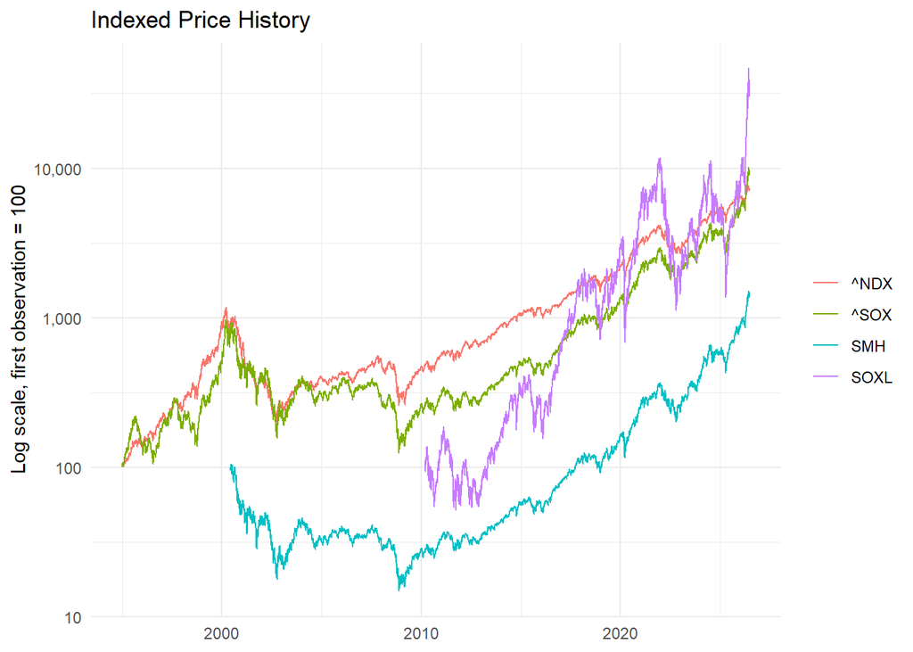

```r
prices |>
  filter(symbol %in% c("^SOX", "^NDX", "SOXL", "SMH")) |>
  group_by(symbol) |>
  arrange(date, .by_group = TRUE) |>
  mutate(indexed = adj_close / first(adj_close) * 100) |>
  ungroup() |>
  ggplot(aes(date, indexed, color = symbol)) +
  geom_line(linewidth = 0.45) +
  scale_y_log10(labels = comma) +
  labs(title = "Indexed Price History", x = NULL, y = "Log scale, first observation = 100", color = NULL) +
  theme_minimal()
```

# 5 SOX vs Nasdaq 100

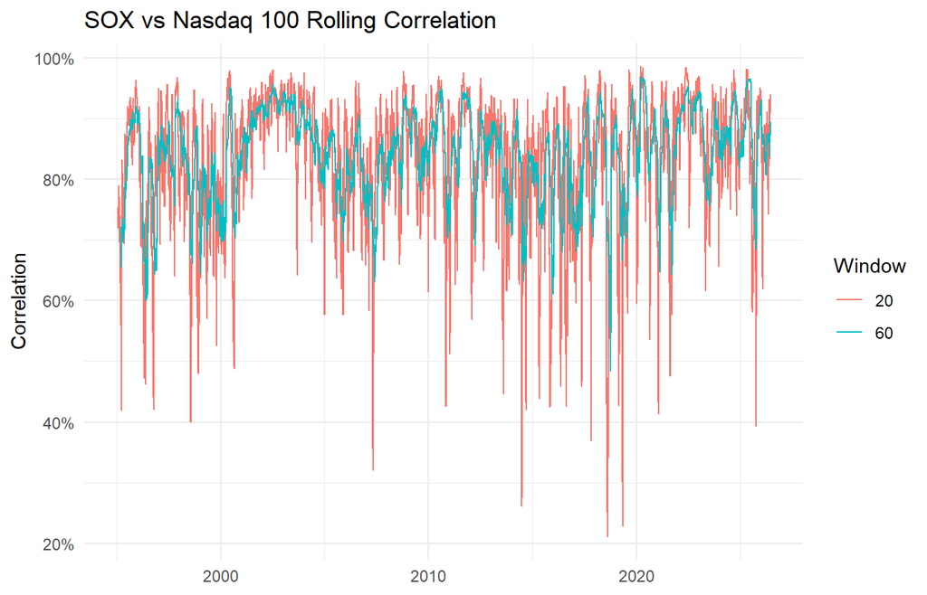

```r
rolling_cor_tbl |>
  filter(metric == "cor") |>
  ggplot(aes(date, value, color = factor(window))) +
  geom_line(linewidth = 0.45, na.rm = TRUE) +
  scale_y_continuous(labels = percent) +
  labs(title = "SOX vs Nasdaq 100 Rolling Correlation", x = NULL, y = "Correlation", color = "Window") +
  theme_minimal()
```

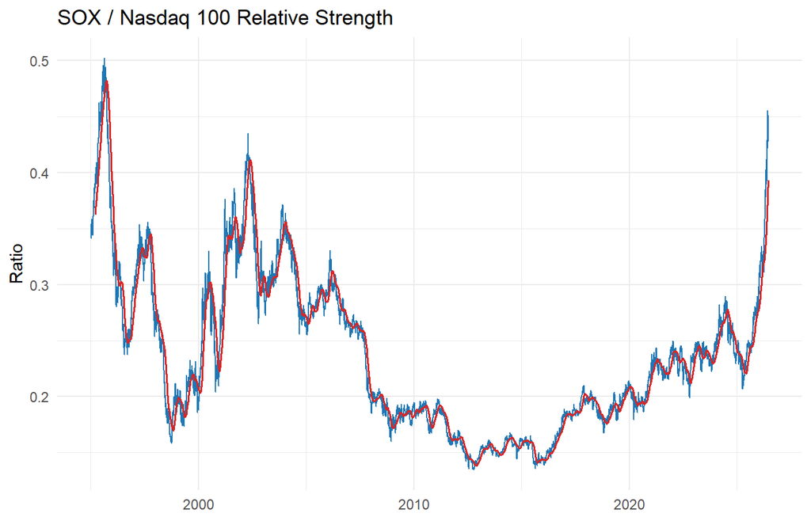

```r
rs_tbl |>
  ggplot(aes(date, ratio)) +
  geom_line(color = "#1f77b4", linewidth = 0.45) +
  geom_line(aes(y = ratio_ma50), color = "#d62728", linewidth = 0.55, na.rm = TRUE) +
  labs(title = "SOX / Nasdaq 100 Relative Strength", x = NULL, y = "Ratio") +
  theme_minimal()
```

# 6 SOX vs UST10Y

The rate beta uses daily changes in the Yahoo Finance `^TNX` series as a proxy for 10-year Treasury yield changes. A negative beta means SOX tends to fall when yields rise.

```r
tibble(
  sox_daily_beta_to_tnx_change = analysis_data$rate_beta
) |>
  mutate(sox_daily_beta_to_tnx_change = round(sox_daily_beta_to_tnx_change, 4)) |>
  knitr::kable()
```

| sox_daily_beta_to_tnx_change |
| --- |
| 0.0763 |

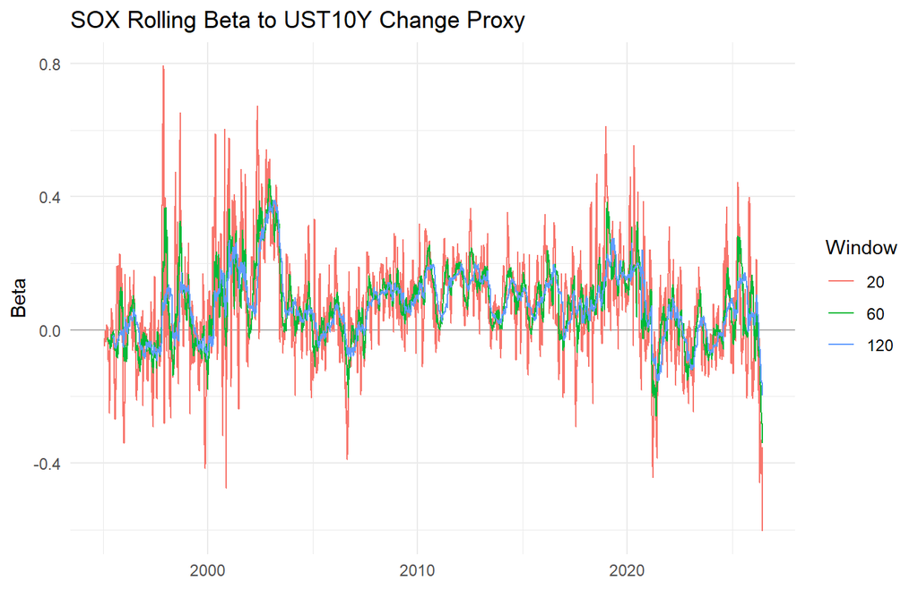

```r
rolling_rate_beta_tbl |>
  ggplot(aes(date, value, color = factor(window))) +
  geom_hline(yintercept = 0, color = "grey70") +
  geom_line(linewidth = 0.45, na.rm = TRUE) +
  labs(title = "SOX Rolling Beta to UST10Y Change Proxy", x = NULL, y = "Beta", color = "Window") +
  theme_minimal()
```

# 7 Constituent Influence

```r
contribution_tbl |>
  select(ticker, company, industry_group, ai_sensitivity, correlation, beta_to_sox, annual_vol, contribution_score) |>
  mutate(
    correlation = round(correlation, 2),
    beta_to_sox = round(beta_to_sox, 2),
    annual_vol = percent(annual_vol, accuracy = 0.1),
    contribution_score = round(contribution_score, 4)
  ) |>
  head(15) |>
  knitr::kable()
```

| ticker | company | industry_group | ai_sensitivity | correlation | beta_to_sox | annual_vol | contribution_score |
| --- | --- | --- | --- | --- | --- | --- | --- |
| AMAT | Applied Materials | Equipment | Medium | 0.85 | 0.69 | 46.8% | 0.0108 |
| KLAC | KLA | Equipment | Medium | 0.82 | 0.62 | 50.1% | 0.0104 |
| TXN | Texas Instruments | Analog | Low | 0.81 | 0.77 | 39.9% | 0.0102 |
| LRCX | Lam Research | Equipment | Medium | 0.80 | 0.56 | 54.2% | 0.0101 |
| TER | Teradyne | Equipment | Medium | 0.79 | 0.56 | 53.0% | 0.0100 |
| ADI | Analog Devices | Analog | Low | 0.79 | 0.68 | 43.7% | 0.0099 |
| INTC | Intel | IDM | Medium | 0.73 | 0.68 | 40.8% | 0.0093 |
| ASML | ASML Holding | Equipment | High | 0.72 | 0.57 | 48.2% | 0.0092 |
| MU | Micron Technology | Memory | High | 0.72 | 0.47 | 58.2% | 0.0091 |
| MCHP | Microchip Technology | Analog/MCU | Low | 0.72 | 0.57 | 47.4% | 0.0091 |
| LSCC | Lattice Semiconductor | Fabless | Medium | 0.70 | 0.47 | 56.4% | 0.0089 |
| TSM | Taiwan Semiconductor Manufacturing | Foundry | High | 0.68 | 0.60 | 43.5% | 0.0087 |
| GFS | GLOBALFOUNDRIES | Foundry | Low | 0.68 | 0.50 | 51.2% | 0.0086 |
| ALGM | Allegro MicroSystems | Auto/Power | Low | 0.69 | 0.49 | 51.9% | 0.0085 |
| NVDA | NVIDIA | Fabless | High | 0.67 | 0.43 | 59.3% | 0.0084 |

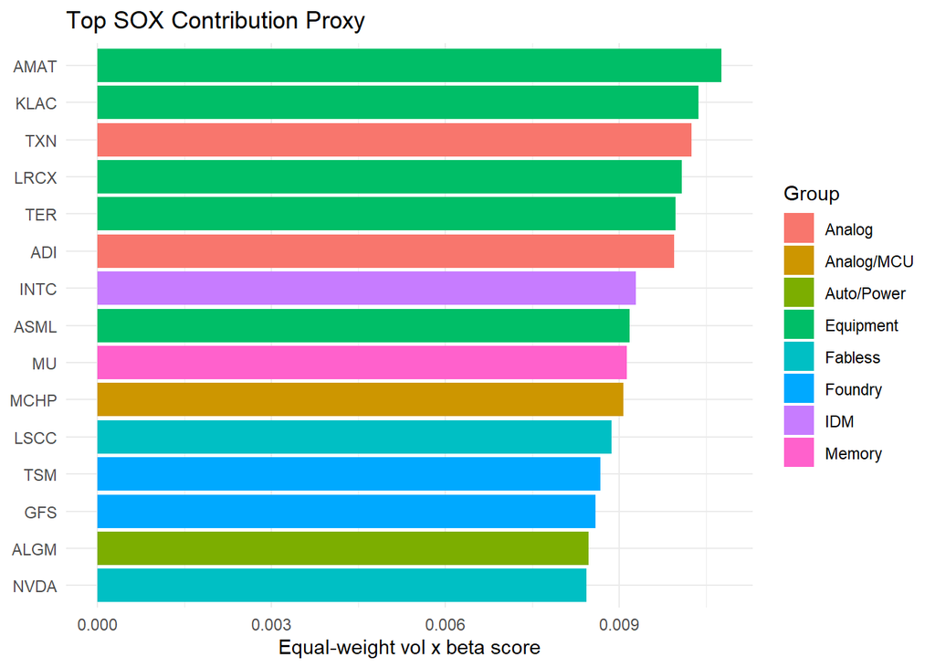

```r
contribution_tbl |>
  slice_max(contribution_score, n = 15) |>
  ggplot(aes(reorder(ticker, contribution_score), contribution_score, fill = industry_group)) +
  geom_col() +
  coord_flip() +
  labs(title = "Top SOX Contribution Proxy", x = NULL, y = "Equal-weight vol x beta score", fill = "Group") +
  theme_minimal()
```

# 8 Lead-Lag Analysis

```r
lead_lag_tbl |>
  mutate(across(c(same_day, stock_leads_1d, sox_leads_1d), ~ round(.x, 3))) |>
  knitr::kable()
```

| ticker | same_day | stock_leads_1d | sox_leads_1d |
| --- | --- | --- | --- |
| AVGO | 0.757 | -0.083 | -0.065 |
| NVDA | 0.671 | -0.036 | 0.018 |
| ASML | 0.724 | -0.026 | 0.016 |
| AMD | 0.634 | -0.023 | 0.017 |
| TSM | 0.683 | -0.020 | -0.003 |
| MU | 0.722 | -0.013 | 0.004 |

# 9 Regime Analysis

```r
regime_tbl |>
  mutate(
    sox_ret20 = percent(sox_ret20, accuracy = 0.1),
    breadth20 = percent(breadth20, accuracy = 0.1),
    ai_ret20 = percent(ai_ret20, accuracy = 0.1),
    tnx_change20_proxy = round(tnx_change20_proxy, 4)
  ) |>
  knitr::kable()
```

| as_of | regime | sox_ret20 | breadth20 | tnx_change20_proxy | ai_ret20 | leading_bucket |
| --- | --- | --- | --- | --- | --- | --- |
| 2026-06-12 | Broad Rally | 15.4% | 86.7% | -0.136 | 14.9% | Memory |

Regime rules are intentionally transparent:

- Broad Rally: SOX is strong and more than 60% of constituents participate.
- Narrow AI Rally: AI-sensitive leaders outperform SOX while breadth is weak.
- Memory Cycle: memory bucket leads the 20-day map.
- Capex Cycle: equipment bucket leads the 20-day map.
- Rate Shock: yields rise while SOX falls.
- Risk Off: SOX has a material 20-day drawdown.

# 10 SOXL Structure

SOXL is a daily leveraged ETF. A useful operating approximation is:

```
SOXL daily return ~= 3 x semiconductor daily return - financing/friction effects
```

The important caveat is path dependency. In high volatility, repeated daily leverage resets can erode returns even if SOX ends near its starting level. For the HTS strategy this means volatility should lower position size, weak relative strength should make over-levels more conservative, and rate shocks should reduce close-position tolerance.

# 11 SOXL Daily Move Profile

Annualized volatility is useful for comparing assets, but operators also need a more tactile question:

```
On a normal day, how much can SOXL move?
How large is today's range compared with history?
```

The table below separates absolute close-to-close move from intraday high-low range. `latest_range_percentile` shows where the latest daily range sits versus the same window’s history.

```r
daily_move_summary_tbl |>
  filter(symbol %in% c("^SOX", "SOXL")) |>
  mutate(
    across(
      c(
        median_abs_daily_return, p90_abs_daily_return, p95_abs_daily_return, p99_abs_daily_return,
        median_intraday_range, p90_intraday_range, p95_intraday_range, p99_intraday_range,
        avg_gap_abs, avg_open_to_close_abs, latest_abs_daily_return, latest_intraday_range,
        latest_range_percentile
      ),
      ~ percent(.x, accuracy = 0.1)
    )
  ) |>
  select(
    symbol, window, observations,
    median_abs_daily_return, p90_abs_daily_return, p95_abs_daily_return, p99_abs_daily_return,
    median_intraday_range, p90_intraday_range, p95_intraday_range, p99_intraday_range,
    latest_date, latest_intraday_range, latest_range_percentile
  ) |>
  knitr::kable()
```

| symbol | window | observations | median_abs_daily_return | p90_abs_daily_return | p95_abs_daily_return | p99_abs_daily_return | median_intraday_range | p90_intraday_range | p95_intraday_range | p99_intraday_range | latest_date | latest_intraday_range | latest_range_percentile |
| --- | --- | --- | --- | --- | --- | --- | --- | --- | --- | --- | --- | --- | --- |
| SOXL | Full | 4089 | 3.0% | 9.0% | 11.8% | 17.3% | 5.4% | 11.1% | 13.6% | 20.8% | 2026-06-12 | 12.9% | 93.9% |
| SOXL | Last 10Y | 2520 | 3.3% | 9.8% | 13.0% | 19.2% | 5.9% | 12.0% | 15.5% | 23.8% | 2026-06-12 | 12.9% | 91.7% |
| SOXL | Last 5Y | 1260 | 3.9% | 11.0% | 13.8% | 19.7% | 6.9% | 13.1% | 16.8% | 25.3% | 2026-06-12 | 12.9% | 89.3% |
| SOXL | Last 3Y | 756 | 3.8% | 10.4% | 13.2% | 21.9% | 6.4% | 12.4% | 16.7% | 28.4% | 2026-06-12 | 12.9% | 90.9% |
| SOXL | Last 1Y | 252 | 3.8% | 11.9% | 14.5% | 19.2% | 6.5% | 13.7% | 18.7% | 26.9% | 2026-06-12 | 12.9% | 87.7% |
| SOXL | Last 60D | 60 | 6.7% | 16.4% | 18.5% | 26.7% | 8.9% | 20.1% | 22.2% | 36.0% | 2026-06-12 | 12.9% | 76.7% |
| SOXL | Last 20D | 20 | 6.6% | 19.0% | 24.3% | 29.3% | 11.8% | 23.0% | 29.4% | 43.2% | 2026-06-12 | 12.9% | 60.0% |
| ^SOX | Full | 7913 | 1.2% | 3.9% | 5.0% | 7.7% | 2.2% | 5.0% | 6.5% | 9.4% | 2026-06-12 | 4.1% | 83.3% |
| ^SOX | Last 10Y | 2520 | 1.1% | 3.4% | 4.4% | 6.4% | 1.9% | 3.7% | 4.6% | 6.9% | 2026-06-12 | 4.1% | 92.3% |
| ^SOX | Last 5Y | 1260 | 1.3% | 3.7% | 4.6% | 6.8% | 2.2% | 4.1% | 5.0% | 7.3% | 2026-06-12 | 4.1% | 90.1% |
| ^SOX | Last 3Y | 756 | 1.3% | 3.6% | 4.5% | 7.3% | 2.0% | 3.9% | 4.9% | 7.5% | 2026-06-12 | 4.1% | 91.1% |
| ^SOX | Last 1Y | 252 | 1.3% | 3.9% | 4.8% | 6.3% | 2.1% | 4.2% | 5.7% | 7.3% | 2026-06-12 | 4.1% | 88.1% |
| ^SOX | Last 60D | 60 | 2.1% | 5.5% | 6.2% | 8.9% | 2.9% | 5.8% | 6.5% | 9.4% | 2026-06-12 | 4.1% | 76.7% |
| ^SOX | Last 20D | 20 | 2.1% | 6.1% | 8.0% | 9.8% | 3.8% | 6.6% | 7.6% | 11.5% | 2026-06-12 | 4.1% | 60.0% |

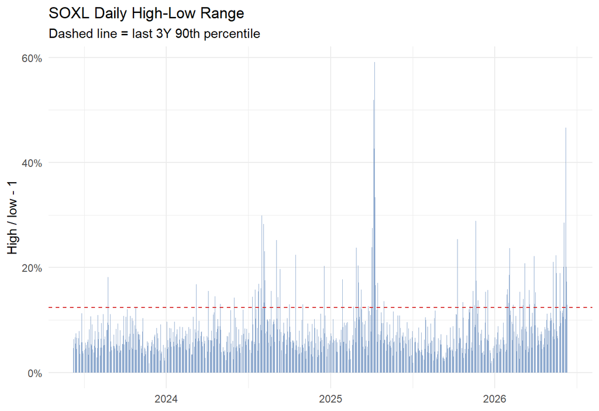

```r
daily_move_features_tbl |>
  filter(symbol == "SOXL") |>
  slice_tail(n = 756) |>
  ggplot(aes(date, intraday_range)) +
  geom_col(fill = "#6b8fbf", alpha = 0.75) +
  geom_hline(
    data = daily_move_summary_tbl |> filter(symbol == "SOXL", window == "Last 3Y"),
    aes(yintercept = p90_intraday_range),
    color = "#d62728",
    linetype = "dashed"
  ) +
  scale_y_continuous(labels = percent) +
  labs(
    title = "SOXL Daily High-Low Range",
    subtitle = "Dashed line = last 3Y 90th percentile",
    x = NULL,
    y = "High / low - 1"
  ) +
  theme_minimal()
```

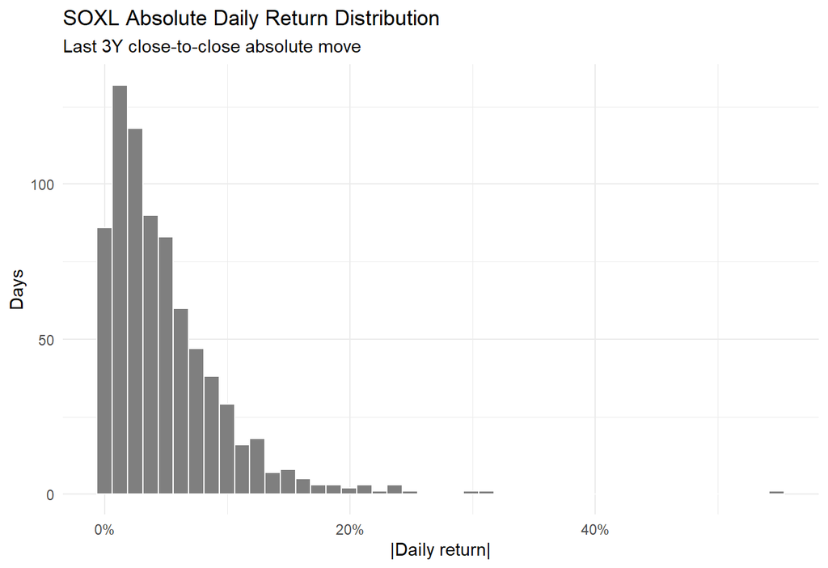

```r
daily_move_features_tbl |>
  filter(symbol == "SOXL") |>
  slice_tail(n = 756) |>
  ggplot(aes(abs_daily_return)) +
  geom_histogram(bins = 45, fill = "#7f7f7f", color = "white") +
  scale_x_continuous(labels = percent) +
  labs(
    title = "SOXL Absolute Daily Return Distribution",
    subtitle = "Last 3Y close-to-close absolute move",
    x = "|Daily return|",
    y = "Days"
  ) +
  theme_minimal()
```

Operating interpretation:

- Median daily range is the normal noise band.
- 90th percentile range is a high-volatility day; reduce unit size and avoid dense re-hit orders.
- 95th to 99th percentile range is stress territory; close-position and losscut guard matter more than anchor aggressiveness.

# 12 VIX and SOXL Daily Move

VIX is not used here as a directional signal by itself. The first use is simpler and more operational:

```
Given the VIX regime, what daily SOXL move should we expect?
```

The table below groups history by VIX level and measures SOXL close-to-close absolute move and intraday high-low range. This helps set unit size, re-hit spacing, losscut tolerance, and close-position aggressiveness.

```r
vix_soxl_level_summary_tbl |>
  mutate(
    across(
      c(
        avg_same_day_soxl, median_same_day_soxl, win_rate_same_day,
        avg_next_1d_soxl, win_rate_next_1d, avg_next_5d_soxl, win_rate_next_5d,
        avg_abs_soxl_move, median_abs_soxl_move, p90_abs_soxl_move, p95_abs_soxl_move,
        median_soxl_intraday_range, p90_soxl_intraday_range, p95_soxl_intraday_range
      ),
      ~ percent(.x, accuracy = 0.1)
    )
  ) |>
  select(
    vix_bucket, n,
    median_abs_soxl_move, p90_abs_soxl_move, p95_abs_soxl_move,
    median_soxl_intraday_range, p90_soxl_intraday_range, p95_soxl_intraday_range,
    avg_next_1d_soxl, win_rate_next_1d
  ) |>
  knitr::kable()
```

| vix_bucket | n | median_abs_soxl_move | p90_abs_soxl_move | p95_abs_soxl_move | median_soxl_intraday_range | p90_soxl_intraday_range | p95_soxl_intraday_range | avg_next_1d_soxl | win_rate_next_1d |
| --- | --- | --- | --- | --- | --- | --- | --- | --- | --- |
| 15 <= VIX < 20 | 1463 | 3.1% | 8.1% | 9.8% | 5.4% | 9.7% | 11.3% | 0.1% | 52.8% |
| 20 <= VIX < 25 | 638 | 3.9% | 11.0% | 13.2% | 7.2% | 12.4% | 14.6% | 0.5% | 54.1% |
| 25 <= VIX < 30 | 294 | 4.4% | 13.1% | 15.8% | 8.6% | 13.9% | 17.9% | 0.7% | 53.7% |
| VIX < 15 | 1438 | 2.1% | 6.1% | 7.5% | 3.9% | 7.0% | 8.4% | 0.2% | 54.5% |
| VIX >= 30 | 256 | 6.5% | 15.5% | 19.1% | 11.0% | 20.6% | 29.0% | 1.0% | 54.3% |

```r
vix_soxl_change_summary_tbl |>
  mutate(
    across(
      c(
        avg_same_day_soxl, win_rate_same_day, avg_next_1d_soxl, win_rate_next_1d,
        avg_abs_soxl_move, median_abs_soxl_move, p90_abs_soxl_move, p95_abs_soxl_move,
        median_soxl_intraday_range, p90_soxl_intraday_range, p95_soxl_intraday_range
      ),
      ~ percent(.x, accuracy = 0.1)
    )
  ) |>
  select(
    vix_change_bucket, n,
    median_abs_soxl_move, p90_abs_soxl_move, p95_abs_soxl_move,
    median_soxl_intraday_range, p90_soxl_intraday_range, p95_soxl_intraday_range,
    avg_same_day_soxl, avg_next_1d_soxl
  ) |>
  knitr::kable()
```

| vix_change_bucket | n | median_abs_soxl_move | p90_abs_soxl_move | p95_abs_soxl_move | median_soxl_intraday_range | p90_soxl_intraday_range | p95_soxl_intraday_range | avg_same_day_soxl | avg_next_1d_soxl |
| --- | --- | --- | --- | --- | --- | --- | --- | --- | --- |
| VIX down | 1942 | 2.7% | 7.6% | 9.4% | 5.0% | 9.5% | 11.2% | 2.2% | 0.3% |
| VIX down >= 2pt | 272 | 6.2% | 14.4% | 16.7% | 7.7% | 15.8% | 18.1% | 7.0% | -0.2% |
| VIX up >= 2pt | 316 | 7.6% | 15.2% | 17.9% | 9.6% | 18.5% | 23.1% | -8.4% | 1.0% |
| VIX up mild | 1559 | 2.4% | 7.2% | 8.9% | 5.1% | 10.2% | 12.1% | -1.4% | 0.3% |

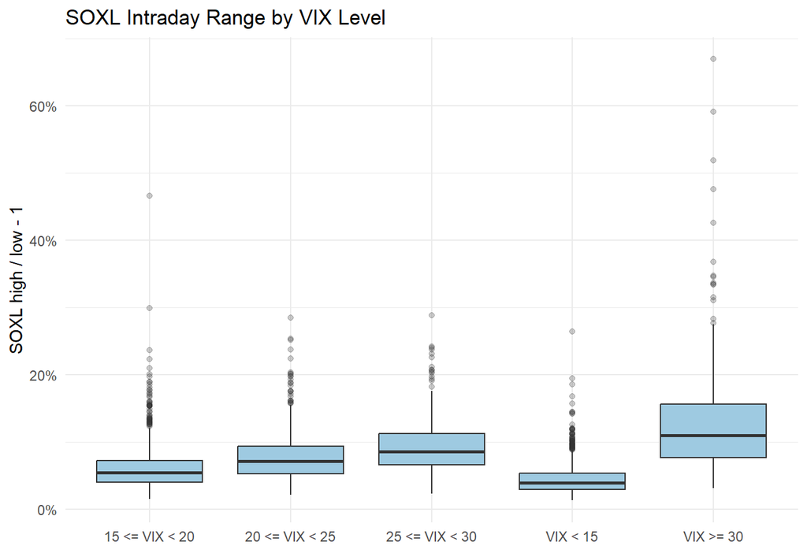

```r
vix_soxl_daily_tbl |>
  filter(is.finite(vix_level), is.finite(SOXL_intraday_range)) |>
  ggplot(aes(vix_bucket, SOXL_intraday_range)) +
  geom_boxplot(fill = "#9ecae1", outlier.alpha = 0.25) +
  scale_y_continuous(labels = percent) +
  labs(
    title = "SOXL Intraday Range by VIX Level",
    x = NULL,
    y = "SOXL high / low - 1"
  ) +
  theme_minimal()
```

```r
vix_soxl_latest_tbl |>
  mutate(
    vix_pct_change = percent(vix_pct_change, accuracy = 0.1),
    soxl_same_day_return = percent(soxl_same_day_return, accuracy = 0.1),
    soxl_abs_move = percent(soxl_abs_move, accuracy = 0.1),
    soxl_intraday_range = percent(soxl_intraday_range, accuracy = 0.1)
  ) |>
  knitr::kable()
```

| as_of | vix_level | vix_change | vix_pct_change | vix_bucket | vix_change_bucket | soxl_same_day_return | soxl_abs_move | soxl_intraday_range | vix_risk_level |
| --- | --- | --- | --- | --- | --- | --- | --- | --- | --- |
| 2026-06-12 | 17.68 | -1.76 | -9.1% | 15 <= VIX < 20 | VIX down | 4.8% | 4.8% | 12.9% | Green |

Operating interpretation:

- Low VIX with low SOXL range: normal unit size and normal under/over spacing.
- Rising VIX with expanding SOXL range: reduce unit size and avoid same-level overtrading.
- VIX 25+ or VIX jump days: treat intraday rebounds more skeptically and require stronger VWAP/recovery confirmation.

# 13 SOXL Volatility Decay

This section turns the leverage caveat into a daily operating number. `Decay` is defined as:

```
SOXL return - 3 x SOX return
```

Positive values mean SOXL outperformed a simple 3x SOX approximation over the period. Negative values indicate volatility drag, financing/friction, or path dependency.

```r
decay_tbl |>
  mutate(
    across(c(sox_return, soxl_return, theoretical_3x_sox, decay), ~ percent(.x, accuracy = 0.1))
  ) |>
  knitr::kable()
```

| period | n_obs | start_date | end_date | sox_return | soxl_return | theoretical_3x_sox | decay |
| --- | --- | --- | --- | --- | --- | --- | --- |
| 20D | 20 | 2026-05-15 | 2026-06-12 | 10.7% | 26.0% | 32.2% | -6.2% |
| 60D | 60 | 2026-03-19 | 2026-06-12 | 71.5% | 334.4% | 214.6% | 119.8% |
| 120D | 120 | 2025-12-19 | 2026-06-12 | 94.8% | 508.3% | 284.4% | 223.8% |
| 252D | 252 | 2025-06-12 | 2026-06-12 | 155.5% | 988.2% | 466.6% | 521.6% |

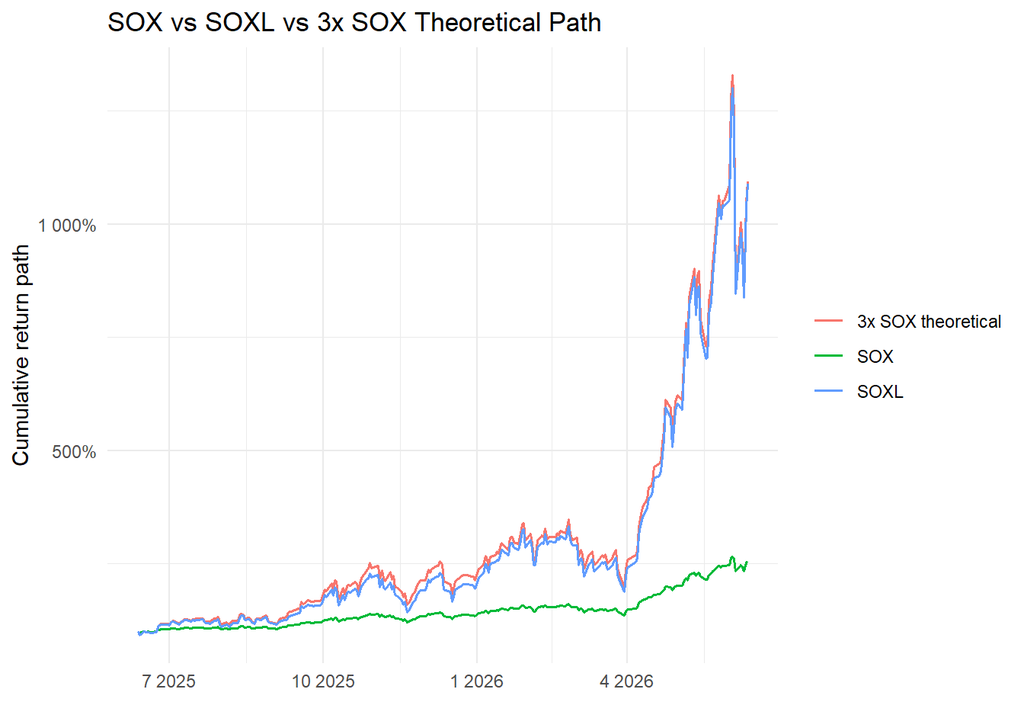

```r
decay_path_tbl |>
  ggplot(aes(date, indexed, color = series)) +
  geom_line(linewidth = 0.55, na.rm = TRUE) +
  scale_y_continuous(labels = percent) +
  labs(title = "SOX vs SOXL vs 3x SOX Theoretical Path", x = NULL, y = "Cumulative return path", color = NULL) +
  theme_minimal()
```

# 14 Breadth Analysis

Breadth answers whether the semiconductor move is broad or concentrated. For SOXL, broad participation supports higher confidence; narrow rallies deserve more conservative anchors and smaller close exposure.

```r
breadth_tbl |>
  slice_tail(n = 10) |>
  mutate(breadth = percent(breadth, accuracy = 0.1)) |>
  knitr::kable()
```

| date | advancing | declining | total | breadth | breadth_state |
| --- | --- | --- | --- | --- | --- |
| 2026-06-01 | 13 | 17 | 30 | 43.3% | Mixed |
| 2026-06-02 | 28 | 2 | 30 | 93.3% | Broad Rally |
| 2026-06-03 | 23 | 7 | 30 | 76.7% | Broad Rally |
| 2026-06-04 | 11 | 19 | 30 | 36.7% | Narrow Rally |
| 2026-06-05 | 0 | 30 | 30 | 0.0% | Narrow Rally |
| 2026-06-08 | 30 | 0 | 30 | 100.0% | Broad Rally |
| 2026-06-09 | 10 | 20 | 30 | 33.3% | Narrow Rally |
| 2026-06-10 | 0 | 30 | 30 | 0.0% | Narrow Rally |
| 2026-06-11 | 30 | 0 | 30 | 100.0% | Broad Rally |
| 2026-06-12 | 24 | 6 | 30 | 80.0% | Broad Rally |

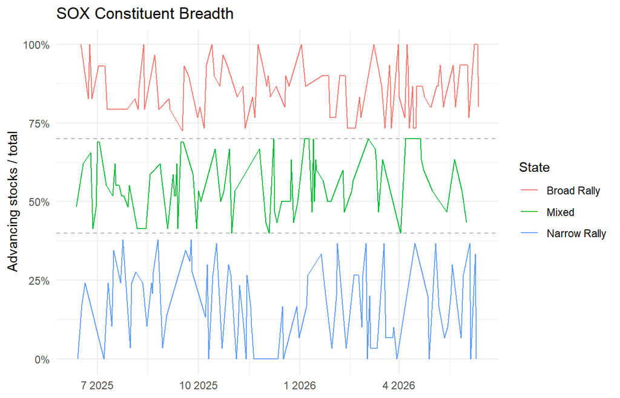

```r
breadth_tbl |>
  slice_tail(n = 252) |>
  ggplot(aes(date, breadth, color = breadth_state)) +
  geom_hline(yintercept = c(0.4, 0.7), color = "grey70", linetype = "dashed") +
  geom_line(linewidth = 0.45) +
  scale_y_continuous(labels = percent) +
  labs(title = "SOX Constituent Breadth", x = NULL, y = "Advancing stocks / total", color = "State") +
  theme_minimal()
```

# 15 Semiconductor Sector Rotation

The sector rotation table shows where SOX strength is coming from. This helps distinguish a broad semiconductor move from a concentrated AI, memory, capex, analog, or power cycle.

```r
sector_rotation_tbl |>
  mutate(
    avg_return = percent(avg_return, accuracy = 0.1),
    volatility = percent(volatility, accuracy = 0.1),
    relative_strength = percent(relative_strength, accuracy = 0.1)
  ) |>
  arrange(period, desc(relative_strength)) |>
  knitr::kable()
```

| industry_group | period | n_stock | avg_return | volatility | relative_strength |
| --- | --- | --- | --- | --- | --- |
| Memory | 20D | 1 | 35.5% | 117.0% | 20.1% |
| Packaging | 20D | 1 | 17.8% | 90.6% | 2.4% |
| Equipment | 20D | 6 | 26.6% | 74.6% | 11.2% |
| Auto/Power | 20D | 1 | 16.9% | 93.2% | 1.6% |
| Fabless/IP | 20D | 1 | 15.4% | 100.7% | 0.0% |
| RF | 20D | 2 | 7.9% | 64.3% | -7.5% |
| Foundry | 20D | 2 | 9.8% | 73.6% | -5.6% |
| Power | 20D | 2 | -13.7% | 121.2% | -29.0% |
| Materials | 20D | 1 | 13.1% | 77.9% | -2.3% |
| Analog | 20D | 2 | -0.1% | 51.7% | -15.5% |
| Materials/Photonics | 20D | 1 | 0.7% | 101.0% | -14.7% |
| Analog/Power | 20D | 1 | 1.8% | 71.8% | -13.6% |
| Analog/MCU | 20D | 1 | 2.0% | 57.5% | -13.4% |
| Auto/MCU | 20D | 1 | 4.6% | 59.8% | -10.8% |
| Fabless | 20D | 6 | 14.3% | 92.8% | -1.1% |
| IDM | 20D | 1 | 14.5% | 85.0% | -0.9% |
| IDM | 60D | 1 | 169.7% | 96.3% | 99.7% |
| Power | 60D | 2 | 124.9% | 115.3% | 54.9% |
| Memory | 60D | 1 | 121.0% | 95.8% | 51.0% |
| Packaging | 60D | 1 | 72.2% | 79.3% | 2.1% |
| Fabless | 60D | 6 | 85.1% | 74.1% | 15.1% |
| Equipment | 60D | 6 | 60.2% | 68.8% | -9.9% |
| Auto/Power | 60D | 1 | 63.1% | 76.3% | -7.0% |
| Materials | 60D | 1 | 30.0% | 66.8% | -40.0% |
| RF | 60D | 2 | 32.3% | 53.4% | -37.7% |
| Materials/Photonics | 60D | 1 | 39.7% | 89.4% | -30.3% |
| Analog/Power | 60D | 1 | 44.6% | 62.1% | -25.4% |
| Analog | 60D | 2 | 47.8% | 49.1% | -22.2% |
| Analog/MCU | 60D | 1 | 51.2% | 50.7% | -18.8% |
| Fabless/IP | 60D | 1 | 54.9% | 98.6% | -15.2% |
| Foundry | 60D | 2 | 56.6% | 59.9% | -13.5% |
| Auto/MCU | 60D | 1 | 59.3% | 68.9% | -10.7% |

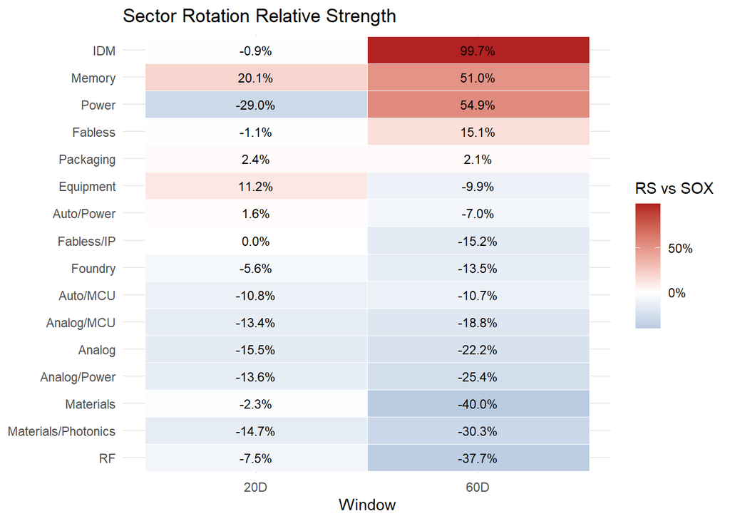

```r
sector_rotation_tbl |>
  ggplot(aes(period, reorder(industry_group, relative_strength), fill = relative_strength)) +
  geom_tile(color = "white") +
  geom_text(aes(label = percent(relative_strength, accuracy = 0.1)), size = 3) +
  scale_fill_gradient2(low = "steelblue", mid = "white", high = "firebrick", midpoint = 0, labels = percent) +
  labs(title = "Sector Rotation Relative Strength", x = "Window", y = NULL, fill = "RS vs SOX") +
  theme_minimal()
```

# 16 Historical Regime Performance

The current regime is more useful when we know how similar historical states behaved for SOXL. The table below summarizes forward SOXL performance by transparent regime label.

```r
regime_perf_tbl |>
  mutate(
    avg_next_5d = percent(avg_next_5d, accuracy = 0.1),
    median_next_5d = percent(median_next_5d, accuracy = 0.1),
    win_rate_5d = percent(win_rate_5d, accuracy = 0.1),
    avg_next_20d = percent(avg_next_20d, accuracy = 0.1),
    median_next_20d = percent(median_next_20d, accuracy = 0.1),
    win_rate_20d = percent(win_rate_20d, accuracy = 0.1)
  ) |>
  knitr::kable()
```

| regime | n | avg_next_5d | median_next_5d | win_rate_5d | avg_next_20d | median_next_20d | win_rate_20d |
| --- | --- | --- | --- | --- | --- | --- | --- |
| Capex Cycle | 121 | 4.2% | 4.2% | 60.0% | 14.1% | 19.1% | 86.7% |
| Rate Shock | 959 | 1.5% | 1.6% | 54.2% | 11.3% | 6.1% | 58.8% |
| Risk Off | 849 | 4.7% | 6.1% | 62.7% | 9.9% | 7.0% | 65.4% |
| Narrow AI Rally | 590 | 1.9% | 1.7% | 57.8% | 9.0% | 8.3% | 67.1% |
| Memory Cycle | 474 | 0.6% | 1.0% | 56.5% | 7.0% | 7.3% | 62.6% |
| Broad Rally | 1992 | 2.0% | 1.8% | 59.0% | 6.0% | 6.2% | 63.3% |
| Mixed / Transition | 2870 | 0.4% | 1.2% | 54.6% | 2.0% | 1.9% | 54.2% |

# 17 SOXL Trading Overlay

This is the bridge from market explanation to SOXL operation. It converts regime, breadth, relative strength, volatility, rate beta, and decay into exposure, anchor, and close-position guidance.

```r
operator_overlay_tbl |>
  mutate(
    breadth = percent(breadth, accuracy = 0.1),
    soxl_volatility = percent(soxl_volatility, accuracy = 0.1),
    soxl_decay_20d = percent(soxl_decay_20d, accuracy = 0.1),
    rate_beta_60d = round(rate_beta_60d, 3),
    confidence_score = round(confidence_score, 0)
  ) |>
  select(
    as_of, regime, breadth, breadth_state, relative_strength, leading_sector,
    soxl_volatility, rate_beta_60d, soxl_decay_20d, risk_level,
    exposure_recommendation, confidence_score, anchor_bias, close_position_bias
  ) |>
  knitr::kable()
```

| as_of | regime | breadth | breadth_state | relative_strength | leading_sector | soxl_volatility | rate_beta_60d | soxl_decay_20d | risk_level | exposure_recommendation | confidence_score | anchor_bias | close_position_bias |
| --- | --- | --- | --- | --- | --- | --- | --- | --- | --- | --- | --- | --- | --- |
| 2026-06-12 | Broad Rally | 80.0% | Broad Rally | Strong | Memory | 109.0% | -0.34 | -6.2% | Red | Reduce | 60 | Defensive | Reduce / close |

# 18 SOXL Operator Notes

```r
cat(operator_overlay_tbl$operator_notes[[1]])
```

Regime: Broad Rally | Breadth: 80% | RS: Strong | Leading sector: Memory | Risk: Red | Action: Reduce

# 19 Strategy Implications

```r
signal_tbl |>
  mutate(rate_beta = round(rate_beta, 4)) |>
  knitr::kable()
```

| as_of | current_regime | sox_volatility | relative_strength | rate_beta | suggested_action |
| --- | --- | --- | --- | --- | --- |
| 2026-06-12 | Broad Rally | Moderate | Strong | 0.0763 | Maintain baseline exposure |

Mapping to HTS parameters:

- High SOX volatility: reduce `max_position_qty`, `unit_qty`, and aggressive over-level reuse.
- Strong SOX/NDX relative strength: allow baseline exposure, but confirm breadth before raising anchors.
- Rate Shock or Risk Off: cut close-position ratio and avoid new under-level averaging.
- Broad Rally: anchor can be adjusted upward with normal guardrails.
- Narrow AI Rally: allow participation, but avoid chasing because leadership concentration can reverse quickly.

# 20 Dashboard Design

Recommended Shiny tabs:

- SOX Overview: price, return, volatility, MDD, crash count.
- Regime: current label, 20-day SOX return, breadth, leading bucket.
- SOXL Intelligence: regime, breadth, sector rotation, decay, exposure recommendation, and operator notes.
- Relative Strength: SOX/NDX ratio and moving average state.
- Rate Sensitivity: rolling beta to UST10Y change proxy.
- Top Contributors: contribution score ranking and industry split.
- Strategy Signal: current action, exposure stance, anchor guidance.

# 21 Limitations

- Constituent weights are equal-weight fallbacks unless an official weight file is supplied.
- Yahoo Finance adjusted prices can revise historical data.
- `^TNX` is a yield index proxy and should be cross-checked against Treasury time series for production decisions.
- Regime labels are rules, not a trained classifier.

# 22 Next Step

The next production upgrade is to pipe `signal_tbl` into the US SOXL strategy state sheet as a read-only advisory field, then later gate anchor aggressiveness only after live review.